# Manuscript code - differential feature abundance - try-out

Stefano Mangiola 2023-12-03

Trying out Manuscript code differential feature abundance https://github.com/stemangiola/tidybulk/blob/master/dev/manuscript_differential_transcript_abundance.Rmd tidybulk paper = https://genomebiology.biomedcentral.com/articles/10.1186/s13059-020-02233-7

add renv for tracking package management as environment may influence tidybulk functioning. renv was added after this tidybulk example notebook was initiated and run (execute/initiate renv only once)

note renv snapshot looks for package dependencies throughout the R project - including in several tidybulk test notebooks I added from other sources. Some of these (older) tidybulk test notebooks differ in package environment and renv therefore auto-detects all packages across notebooks - some of which may not be required in newer tidybulk versions, or not true tidybulk requirements but rather notebook example specific packages.

after snapshot choose option 2: Install the packages, then snapshot. this throws error “Error: package ‘nanny’ is not available” - nanny package https://github.com/stemangiola/nanny is not longer maintained - superseeded by tidybulk note that renv sets the libpaths to project local

verify some renv settings

install packages not captured by renv::snapshot() installation (execute only once)

also install required bioconductor packages (execute only once)

check bioconductor packages install

bioconductor::install throws warning message” ” Installation paths not writeable, unable to update packages path: /Users/joostgroot/Library/Caches/org.R-project.R/R/renv/sandbox/R-4.3/aarch64-apple-darwin20/ac5c2659 packages: cluster, foreign, KernSmooth, lattice, Matrix, mgcv, nlme, rpart, spatial, survival ”  
ignore this warning - these packages were updated/installed manually and verified also - BiocManager::valid() gives TRUE indicating now issues

continue below with existing notebook code - first step is loading installed libraries and setting theme

```r
library(knitr)
#library(kableExtra)
# knitr::opts_chunk$set(cache = TRUE, warning = FALSE,
#                       message = FALSE, cache.lazy = FALSE)
#options(width = 120)
options(pillar.min_title_chars = Inf)

library(magrittr)
library(tibble)
library(dplyr)
library(magrittr)
library(tidyr)
library(ggplot2)
library(rlang)
library(purrr)
library(ggrepel)
library(tidyHeatmap)
library(pasilla)
library(tidybulk)

my_theme =
    theme_bw() +
    theme(
        panel.border = element_blank(),
        axis.line = element_line(),
        panel.grid.major = element_line(size = 0.2),
        panel.grid.minor = element_line(size = 0.1),
        text = element_text(size=12),
        legend.position="bottom",
        aspect.ratio=1,
        strip.background = element_blank(),
        axis.title.x  = element_text(margin = margin(t = 10, r = 10, b = 10, l = 10)),
        axis.title.y  = element_text(margin = margin(t = 10, r = 10, b = 10, l = 10))
    )
```

# Load data from pasilla dataset

```r
pasCts = system.file("extdata",
                                         "pasilla_gene_counts.tsv",
                                         package = "pasilla",
                                         mustWork = TRUE)
pasAnno = system.file(
    "extdata",
    "pasilla_sample_annotation.csv",
    package = "pasilla",
    mustWork = TRUE
)
cts = as.matrix(read.csv(pasCts, sep = "\t", row.names = "gene_id"))
coldata = read.csv(pasAnno, row.names = 1)
coldata = coldata[, c("condition", "type")]

# Create tidybulk object
counts =
    cts %>%
    as_tibble(rownames = "feature") %>%
    pivot_longer(names_to = "sample",
                             values_to = "count",
                             cols = -feature) %>%
    left_join(
        coldata %>%
        as_tibble(rownames = "sample") %>%
        mutate(sample = gsub("fb", "", sample))
    ) %>%
    mutate_if(is.character, as.factor)
```

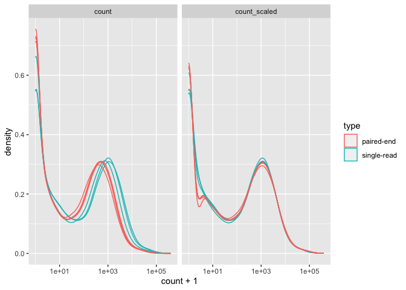

```r
# Create a tt object with unique raw and normalised counts
tt_scaled <-
    tidybulk(counts, sample, feature, count) %>%
    aggregate_duplicates() %>%
    identify_abundant() %>%
    scale_abundance()

# Plot count densities
tt_scaled %>%
    pivot_longer(
        c(count, count_scaled),
        values_to = "count",
        names_to = "Normalisation"
    ) %>%
    ggplot(aes(count + 1, group=sample, color=type)) +
    facet_grid(~Normalisation) +
    geom_density() +
    scale_x_log10()
```

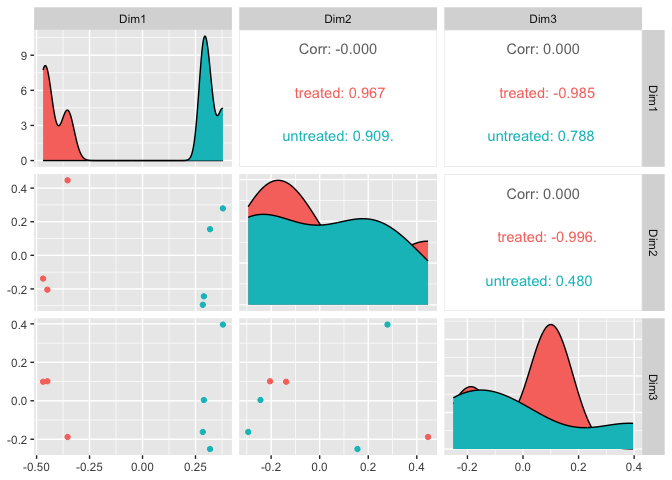

```r
# Reduce data dimensionality with arbitrary number of dimensions
tt_mds <- tt_scaled %>% reduce_dimensions(method="MDS", .dims = 3)

# Plot all-vs-all MDS dimensions
tt_mds %>%
    pivot_sample() %>%
    GGally::ggpairs(columns = 7:9, ggplot2::aes(colour=condition))
```

```r
# Adjust for visualisation
tt_adj <- tt_mds %>% adjust_abundance(~ condition + type)
```

```
## Found 2 batches
## Using null model in ComBat-seq.
## Adjusting for 1 covariate(s) or covariate level(s)
## Estimating dispersions
## Fitting the GLM model
## Shrinkage off - using GLM estimates for parameters
## Adjusting the data
```

```r
# Visualise the association between reduced dimensions and factors
tt_mds_adj_mds <-
    tt_adj %>%
    filter( count_scaled_adjusted %>% is.na %>% `!`) %>%

    # Calculate reduced dimensions on the adjusted counts as well
    reduce_dimensions(
       .abundance = count_scaled_adjusted,
       method="MDS", .dim = 3
    )
```

OLD NOTES from running first version of notebook (first time running notebook) when earlier chunks to set up package environment were not added yet:

NOTE tidybulk said it required combat in the adjust_abundance function - then installed sva (package w Combat) and used it for adjustment for unwanted variation this means function adjust_abundance executes batch correction - in this case over paired-end vs single-end - which may not be a very common use case in the documentation a good example of batch correction (giving idea of when to use it) is probably important - batch correction can distort true biological signal a first idea for an example would be multi-site data (maybe TCGA lung squamous vs lung adenocarcinoma? normal lung controls across batches should map on top of each other? look further into this..) UPDATED: stemangiola now added reference to combat in the adjust_abundance documentation

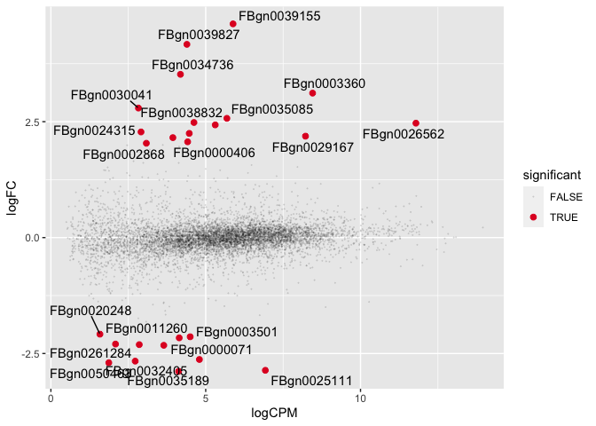

```r
tt_test <- tt_adj %>% test_differential_abundance(~ condition + type)

# MA plot
tt_test %>%
        keep_abundant() %>%
      pivot_transcript() %>%

    # Subset data
    mutate(significant = FDR<0.05 & abs(logFC) >=2) %>%
    mutate(feature = ifelse(significant, as.character(feature), NA)) %>%

    # Plot
    ggplot(aes(x = logCPM, y = logFC, label=feature)) +
    geom_point(aes(color = significant, size = significant, alpha=significant)) +
    geom_text_repel() +
    scale_color_manual(values=c("black", "#e11f28")) +
    scale_size_discrete(range = c(0, 2))
```

type (read type) is used as covariate - as test_differential_abundance takes in raw count data (does its own correction, normalization)

Couple of notes: 1) Looking into test_differential_abundance function documentation it is not clear whether count, count_scaled, or count_scaled_adjusted columns are used as input defaults 2) test_differential_abundance outputs the design columns used and the design column tested - here: (Intercept) - this limited info on what contrast the outputted fold change represents (and also a bit confusing for a novice user) the previous version of tidybulk outputted more elaborate design/contrast info (this seems more an linear modeling default output?)

default diff testing method is edgeR - which outputs logCPM - a per gene expression value it is not very clear what the outputted logCPM represents here - it looks like it is the “Intercept” value of the linear modeling

```r
tt_test %>%

    # Select top genes and reshape data
    inner_join( arrange((.), PValue) %>% distinct(feature) %>% head(6)) %>%

    # High level reshaping of the data.
    # All three count columns are shaped as two columns:
    # (i) the columns name and (ii) the value of those columns
    pivot_longer(
        c(count, count_scaled, count_scaled_adjusted),
        names_to = "Stage", values_to = "count"
    ) %>%

    # This allows the faceted plot
    ggplot(aes(x = Stage, y = count + 1, fill = condition)) +
        geom_boxplot() +
    facet_wrap(~feature) +
    scale_y_log10()
```

[output not shown]

```r
# Heatmap
tt_test %>%
        as_tibble() %>%

    # Select differentially abundant
    filter(FDR < 0.05 & abs(logFC) > 2) %>%

    # Plot
    heatmap( feature, sample, count_scaled_adjusted) %>%
    add_tile(condition) %>%
    add_tile(type)
```

[output not shown]

look at subset of data relevant to differential abundance test

```r
tt_test_diff_abundance_data <- tt_test %>% dplyr::select(feature, sample, count, count_scaled, count_scaled_adjusted, logFC, logCPM, F, PValue, FDR) %>% distinct()
tt_test_diff_abundance_data %>% head(n=20)
```

[output not shown]

then look at fold change differential expression data only

```r
tt_test_diff_abundance_data_FC_only <- tt_test %>% dplyr::select(feature, logFC, logCPM, F, PValue, FDR) %>% distinct()
tt_test_diff_abundance_data_FC_only  %>% head(n=20)
```

[output not shown]

default diff testing method is edgeR - which outputs logCPM - a per gene expression value it is not very clear what the outputted logCPM represents here - it looks like it is the “Intercept” value of the linear modeling

alternative load dataset from tidybulk README.Rmd (does not work?)

```r
# loading this summarized experiment object doesn't work for me - needs to load from dev branch? only have main forked..
# counts_SE = here("dev/counts_SE.rda") |> load()
# counts_SE = here("counts_SE.rda") |> load()
# tibble_counts = counts_SE %>% tidybulk() %>% as_tibble()

# can load se_mini which is used in introduction.Rmd - proceed running functions with se_mini
# data(se_mini)
# tibble_counts.se_mini = tidybulk::se_mini |> tidybulk() |> as_tibble()
```

snapshot libraries installed and display sessionInfo for renv::snapshot() chose for option 1: Snapshot, just using the currently installed packages. snapshot extensively looks for required packages - not all are necessary for this notebook..

```r
renv::snapshot()
sessionInfo()
```

[output not shown]

render notebook to html for local rendered output check and to github_document to check into github

```r
rmarkdown::render("Manuscript_diff_feature_abundance_Joost.Rmd")
```